# Daisy LMMs

Daisy & Matt

2024-05-21

## Design

A 2x2x6 within participant design was employed in the experiment.

1. The first factor relates to the *prioritisation* condition (no prioritisation versus prioritise position 5).
2. The second factor refers to the *suffix* condition (tactile suffix versus no suffix).
3. The third factor refers to the *serial position* (1-6).

As in Roe et al. (2024) each participant completed 48 trials, 4 blocks of 12 tactile sequences. The tactile suffix consisted of a brush stroke across all 6 fingers, Two practice trials preceded each block. The prioritisation condition was blocked, and the order of the block was fully counterbalanced.

## Data

Read the data in from a spreadsheet.

```r
din=read_excel("tactile_prioritisation_suffix_longform.xlsx")
```

Knock the data into its longest form without editing any values.

```r
d=din %>%
  rename(participant=PS) %>%
  rename(block=Block) %>%
  separate_wider_delim(Condition, names=c("priority", "suffix"), delim="/") %>%
  mutate(suffix=tolower(suffix)) %>%
  mutate(priority=tolower(priority)) %>%
  mutate(suffix=str_replace(suffix, " ", "_")) %>%
  mutate(priority=str_replace(priority, " ", "_")) %>%
  group_by(participant) %>%
  mutate(trial=seq_along(participant)) %>%
  ungroup() %>%
  mutate(trial=as_factor(trial)) %>%
  relocate(participant, block, trial) %>%
  pivot_longer(cols=c(Accuary_SP1, Accuary_SP2, Accuary_SP3, Accuary_SP4, Accuary_SP5, Accuary_SP6), values_to="accuracy", names_to="serial_position") %>%
  mutate(serial_position = readr::parse_number(serial_position)) %>%
  mutate(participant=as_factor(participant)) %>%
  #mutate(block=as_factor(block)) %>%
  mutate(serial_position=as_factor(serial_position)) %>%
  mutate(priority = factor(priority, levels=c("no_priority", "p5"), labels=c("PrioritiseNone", "PrioritisePos5"))) %>%
  mutate(suffix = factor(suffix, levels=c("no_suffix", "suffix"), labels=c("SuffAbsent", "SuffPresent")))
```

Test for balanced data

```r
table(d$serial_position, d$priority, d$suffix)
```

```
## , ,  = SuffAbsent
##
##
##     PrioritiseNone PrioritisePos5
##   1            576            576
##   2            576            576
##   3            576            576
##   4            576            576
##   5            576            576
##   6            576            576
##
## , ,  = SuffPresent
##
##
##     PrioritiseNone PrioritisePos5
##   1            576            576
##   2            576            576
##   3            576            576
##   4            576            576
##   5            576            576
##   6            576            576
```

View the first few rows of the longest-form data.

```r
kable(head(d))
```

| participant | block | trial | priority | suffix | serial_position | accuracy |
| --- | --- | --- | --- | --- | --- | --- |
| 1 | 1 | 1 | PrioritiseNone | SuffAbsent | 1 | 1 |
| 1 | 1 | 1 | PrioritiseNone | SuffAbsent | 2 | 1 |
| 1 | 1 | 1 | PrioritiseNone | SuffAbsent | 3 | 1 |
| 1 | 1 | 1 | PrioritiseNone | SuffAbsent | 4 | 0 |
| 1 | 1 | 1 | PrioritiseNone | SuffAbsent | 5 | 0 |
| 1 | 1 | 1 | PrioritiseNone | SuffAbsent | 6 | 0 |

Visualise how accuracy varies across the manipulations of serial_position and priority.

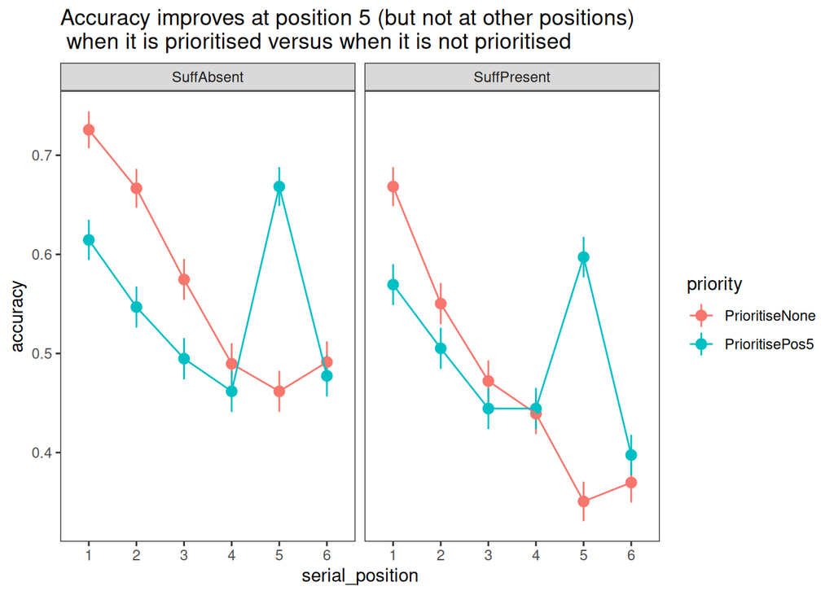

```r
ggplot(data=d, aes(y=accuracy, x=serial_position, colour=priority))+
  facet_wrap(~suffix)+
  stat_summary(fun.data="mean_se")+
  stat_summary(fun.data="mean_se", geom='line', aes(group=priority))+
  theme_bw()+
  theme(panel.grid=element_blank())+
  #scale_x_continuous(breaks=1:6)+
  labs(title = "Accuracy improves at position 5 (but not at other positions)\n when it is prioritised versus when it is not prioritised")
```

## Modelling

Our first model will not try to capture the influence of prioritising position 5 at position 5.

```r
# build the actual model
m1 = glmer(
  data=d,
  family=binomial,
  formula=
        accuracy ~ block + suffix + serial_position + priority +
          (1 | participant) +
          (1 | trial)
)

# just some visual formatting
result_m1 = coef(summary(m1)) %>% as_tibble(rownames="effect") %>%
  rename(p=`Pr(>|z|)`) %>%
  mutate(sig=ifelse(p<.001, "***", ifelse(p<.01, "**", ifelse(p<0.05, "*", ""))))

# show a table
kable(result_m1, digits=3)
```

| effect | Estimate | Std. Error | z value | p | sig |
| --- | --- | --- | --- | --- | --- |
| (Intercept) | 0.723 | 0.206 | 3.505 | 0.000 | *** |
| block | 0.052 | 0.067 | 0.783 | 0.434 |  |
| suffixSuffPresent | -0.333 | 0.037 | -9.097 | 0.000 | *** |
| serial_position2 | -0.365 | 0.064 | -5.688 | 0.000 | *** |
| serial_position3 | -0.688 | 0.064 | -10.735 | 0.000 | *** |
| serial_position4 | -0.860 | 0.064 | -13.381 | 0.000 | *** |
| serial_position5 | -0.583 | 0.064 | -9.108 | 0.000 | *** |
| serial_position6 | -0.973 | 0.064 | -15.100 | 0.000 | *** |
| priorityPrioritisePos5 | -0.013 | 0.037 | -0.355 | 0.722 |  |

In our next model, we particularly want to evaluate the interaction between serial_position and whether position 5 was prioritised or not. We see in the last row of the table that the interaction of serial position and whether we prioritise position 5 is significant.

```r
# build the actual model
m2 = glmer(data=d,
  family=binomial,
  formula=
    accuracy ~ block + suffix + serial_position + priority +
    serial_position : priority +
      (1 | participant) +
      (1 | trial)
  )
# just some visual formatting
result_m2 = coef(summary(m2)) %>% as_tibble(rownames="effect") %>%
  rename(p=`Pr(>|z|)`) %>%
  mutate(sig=ifelse(p<.001, "***", ifelse(p<.01, "**", ifelse(p<0.05, "*", ""))))

# show a table
kable(result_m2, digits=3)
```

| effect | Estimate | Std. Error | z value | p | sig |
| --- | --- | --- | --- | --- | --- |
| (Intercept) | 0.984 | 0.214 | 4.595 | 0.000 | *** |
| block | 0.054 | 0.068 | 0.791 | 0.429 |  |
| suffixSuffPresent | -0.338 | 0.037 | -9.162 | 0.000 | *** |
| serial_position2 | -0.440 | 0.093 | -4.721 | 0.000 | *** |
| serial_position3 | -0.834 | 0.092 | -9.017 | 0.000 | *** |
| serial_position4 | -1.103 | 0.093 | -11.903 | 0.000 | *** |
| serial_position5 | -1.373 | 0.093 | -14.692 | 0.000 | *** |
| serial_position6 | -1.259 | 0.093 | -13.533 | 0.000 | *** |
| priorityPrioritisePos5 | -0.516 | 0.093 | -5.547 | 0.000 | *** |
| serial_position2:priorityPrioritisePos5 | 0.136 | 0.129 | 1.053 | 0.292 |  |
| serial_position3:priorityPrioritisePos5 | 0.272 | 0.129 | 2.116 | 0.034 | * |
| serial_position4:priorityPrioritisePos5 | 0.466 | 0.129 | 3.614 | 0.000 | *** |
| serial_position5:priorityPrioritisePos5 | 1.567 | 0.130 | 12.012 | 0.000 | *** |
| serial_position6:priorityPrioritisePos5 | 0.550 | 0.129 | 4.254 | 0.000 | *** |

Now we try to capture the 3-way interaction between suffix, serial position, and priority. *“…addition of suffix would significantly reduce the prioritisation effect at position 5…”*

```r
# build the actual model
m3 = glmer(
  data=d,
  family=binomial,
  formula=
    accuracy ~ block + suffix + serial_position + priority +
      #serial_position : priority+
      suffix : serial_position : priority +
      (1 | participant) +
      (1 | trial)
    )
```

```
## fixed-effect model matrix is rank deficient so dropping 8 columns / coefficients
```

```r
# just some visual formatting
result_m3 = coef(summary(m3)) %>% as_tibble(rownames="effect") %>%
  rename(p=`Pr(>|z|)`) %>%
  mutate(sig=ifelse(p<.001, "***", ifelse(p<.01, "**", ifelse(p<0.05, "*", ""))))

# show a table
kable(result_m3, digits=3)
```

| effect | Estimate | Std. Error | z value | p | sig |
| --- | --- | --- | --- | --- | --- |
| (Intercept) | 0.424 | 0.314 | 1.352 | 0.176 |  |
| block | 0.054 | 0.068 | 0.791 | 0.429 |  |
| suffixSuffPresent | -0.369 | 0.127 | -2.911 | 0.004 | ** |
| serial_position2 | -0.293 | 0.126 | -2.322 | 0.020 | * |
| serial_position3 | -0.570 | 0.126 | -4.507 | 0.000 | *** |
| serial_position4 | -0.570 | 0.126 | -4.508 | 0.000 | *** |
| serial_position5 | 0.129 | 0.127 | 1.020 | 0.308 |  |
| serial_position6 | -0.788 | 0.127 | -6.180 | 0.000 | *** |
| priorityPrioritisePos5 | 0.138 | 0.129 | 1.066 | 0.286 |  |
| suffixSuffAbsent:serial_position1:priorityPrioritiseNone | 0.538 | 0.259 | 2.083 | 0.037 | * |
| suffixSuffPresent:serial_position1:priorityPrioritiseNone | 0.610 | 0.183 | 3.337 | 0.001 | *** |
| suffixSuffAbsent:serial_position2:priorityPrioritiseNone | 0.522 | 0.257 | 2.034 | 0.042 | * |
| suffixSuffPresent:serial_position2:priorityPrioritiseNone | 0.341 | 0.180 | 1.890 | 0.059 |  |
| suffixSuffAbsent:serial_position3:priorityPrioritiseNone | 0.361 | 0.255 | 1.414 | 0.157 |  |
| suffixSuffPresent:serial_position3:priorityPrioritiseNone | 0.262 | 0.181 | 1.453 | 0.146 |  |
| suffixSuffAbsent:serial_position4:priorityPrioritiseNone | -0.025 | 0.255 | -0.100 | 0.921 |  |
| suffixSuffPresent:serial_position4:priorityPrioritiseNone | 0.111 | 0.181 | 0.615 | 0.539 |  |
| suffixSuffAbsent:serial_position5:priorityPrioritiseNone | -0.851 | 0.256 | -3.331 | 0.001 | *** |
| suffixSuffPresent:serial_position5:priorityPrioritiseNone | -1.010 | 0.183 | -5.524 | 0.000 | *** |
| suffixSuffAbsent:serial_position6:priorityPrioritiseNone | 0.200 | 0.180 | 1.112 | 0.266 |  |
| suffixSuffAbsent:serial_position1:priorityPrioritisePos5 | -0.160 | 0.180 | -0.888 | 0.375 |  |
| suffixSuffAbsent:serial_position2:priorityPrioritisePos5 | -0.180 | 0.179 | -1.008 | 0.313 |  |
| suffixSuffAbsent:serial_position3:priorityPrioritisePos5 | -0.139 | 0.179 | -0.777 | 0.437 |  |
| suffixSuffAbsent:serial_position4:priorityPrioritisePos5 | -0.288 | 0.179 | -1.612 | 0.107 |  |
| suffixSuffAbsent:serial_position5:priorityPrioritisePos5 | -0.027 | 0.181 | -0.151 | 0.880 |  |

```r
d_subset=d %>% filter(serial_position==5)
m4=glmer(data=d_subset,
      family=binomial,
      formula=
        accuracy ~ block + suffix * priority +
        (1 + suffix + priority | participant) +
        (1 + suffix + priority | trial)
)
# just some visual formatting
result_m4 = coef(summary(m4)) %>% as_tibble(rownames="effect") %>%
  rename(p=`Pr(>|z|)`) %>%
  mutate(sig=ifelse(p<.001, "***", ifelse(p<.01, "**", ifelse(p<0.05, "*", ""))))

# show a table
kable(result_m4, digits=3)
```

| effect | Estimate | Std. Error | z value | p | sig |
| --- | --- | --- | --- | --- | --- |
| (Intercept) | -0.535 | 0.250 | -2.136 | 0.033 | * |
| block | 0.141 | 0.078 | 1.802 | 0.071 |  |
| suffixSuffPresent | -0.569 | 0.146 | -3.897 | 0.000 | *** |
| priorityPrioritisePos5 | 0.994 | 0.179 | 5.570 | 0.000 | *** |
| suffixSuffPresent:priorityPrioritisePos5 | 0.202 | 0.189 | 1.068 | 0.286 |  |

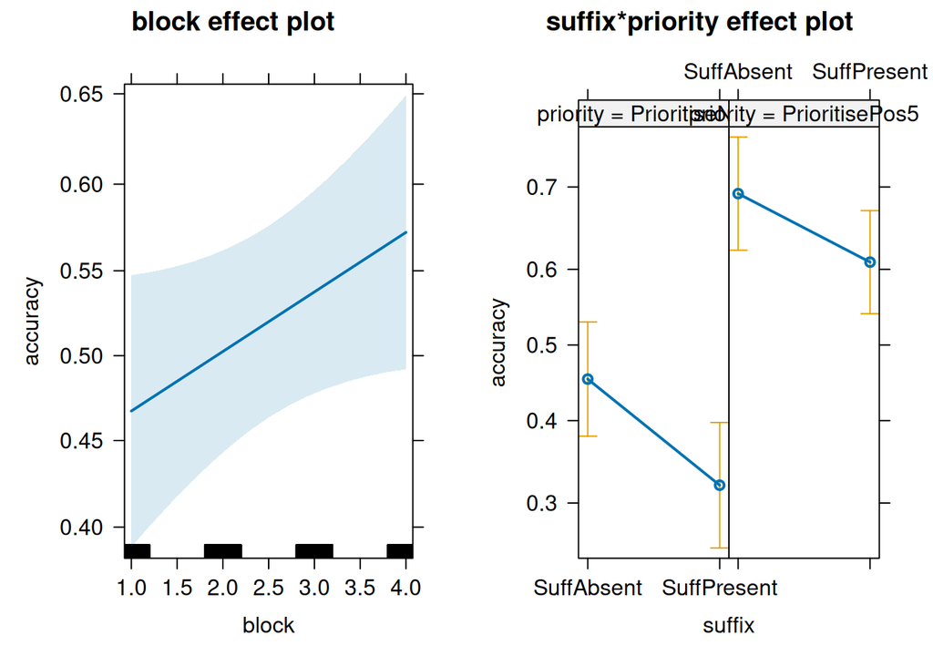

```r
plot(allEffects(m4))
```

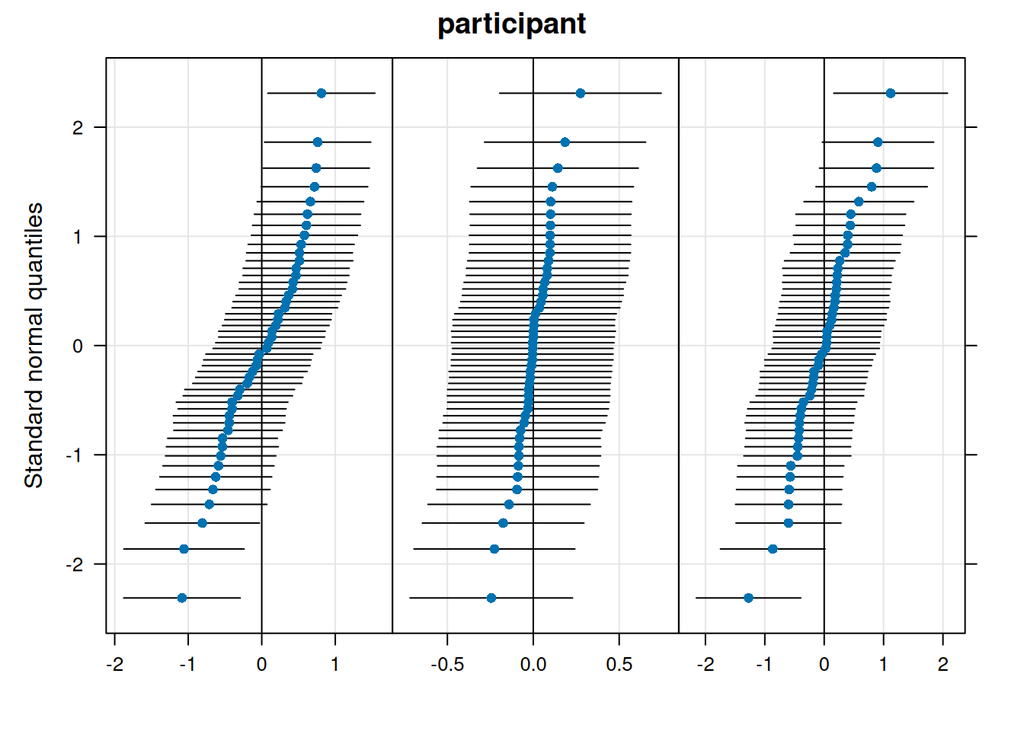

```r
# qqplot of the random effects with their variances
lattice::qqmath(ranef(m4, condVar = TRUE), strip = FALSE)$participant
```

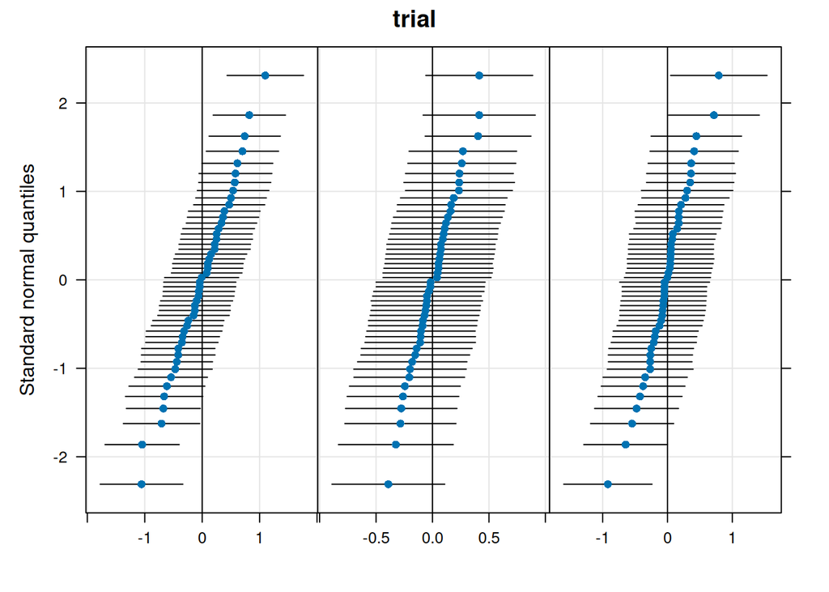

```r
lattice::qqmath(ranef(m4, condVar = TRUE), strip = FALSE)$trial
```

```r
m5=glmer(
     data=d,
     family=binomial,
     formula=
         accuracy ~ block + suffix + serial_position + priority +
         #serial_position : priority+
         suffix : serial_position : priority+
         (1 | participant) +
         (1 | trial)
)
```

```
## fixed-effect model matrix is rank deficient so dropping 8 columns / coefficients
```

```r
# just some visual formatting
result_m5 = coef(summary(m5)) %>% as_tibble(rownames="effect") %>%
  rename(p=`Pr(>|z|)`) %>%
  mutate(sig=ifelse(p<.001, "***", ifelse(p<.01, "**", ifelse(p<0.05, "*", ""))))

# show a table
kable(result_m5, digits=3)
```

| effect | Estimate | Std. Error | z value | p | sig |
| --- | --- | --- | --- | --- | --- |
| (Intercept) | 0.424 | 0.314 | 1.352 | 0.176 |  |
| block | 0.054 | 0.068 | 0.791 | 0.429 |  |
| suffixSuffPresent | -0.369 | 0.127 | -2.911 | 0.004 | ** |
| serial_position2 | -0.293 | 0.126 | -2.322 | 0.020 | * |
| serial_position3 | -0.570 | 0.126 | -4.507 | 0.000 | *** |
| serial_position4 | -0.570 | 0.126 | -4.508 | 0.000 | *** |
| serial_position5 | 0.129 | 0.127 | 1.020 | 0.308 |  |
| serial_position6 | -0.788 | 0.127 | -6.180 | 0.000 | *** |
| priorityPrioritisePos5 | 0.138 | 0.129 | 1.066 | 0.286 |  |
| suffixSuffAbsent:serial_position1:priorityPrioritiseNone | 0.538 | 0.259 | 2.083 | 0.037 | * |
| suffixSuffPresent:serial_position1:priorityPrioritiseNone | 0.610 | 0.183 | 3.337 | 0.001 | *** |
| suffixSuffAbsent:serial_position2:priorityPrioritiseNone | 0.522 | 0.257 | 2.034 | 0.042 | * |
| suffixSuffPresent:serial_position2:priorityPrioritiseNone | 0.341 | 0.180 | 1.890 | 0.059 |  |
| suffixSuffAbsent:serial_position3:priorityPrioritiseNone | 0.361 | 0.255 | 1.414 | 0.157 |  |
| suffixSuffPresent:serial_position3:priorityPrioritiseNone | 0.262 | 0.181 | 1.453 | 0.146 |  |
| suffixSuffAbsent:serial_position4:priorityPrioritiseNone | -0.025 | 0.255 | -0.100 | 0.921 |  |
| suffixSuffPresent:serial_position4:priorityPrioritiseNone | 0.111 | 0.181 | 0.615 | 0.539 |  |
| suffixSuffAbsent:serial_position5:priorityPrioritiseNone | -0.851 | 0.256 | -3.331 | 0.001 | *** |
| suffixSuffPresent:serial_position5:priorityPrioritiseNone | -1.010 | 0.183 | -5.524 | 0.000 | *** |
| suffixSuffAbsent:serial_position6:priorityPrioritiseNone | 0.200 | 0.180 | 1.112 | 0.266 |  |
| suffixSuffAbsent:serial_position1:priorityPrioritisePos5 | -0.160 | 0.180 | -0.888 | 0.375 |  |
| suffixSuffAbsent:serial_position2:priorityPrioritisePos5 | -0.180 | 0.179 | -1.008 | 0.313 |  |
| suffixSuffAbsent:serial_position3:priorityPrioritisePos5 | -0.139 | 0.179 | -0.777 | 0.437 |  |
| suffixSuffAbsent:serial_position4:priorityPrioritisePos5 | -0.288 | 0.179 | -1.612 | 0.107 |  |
| suffixSuffAbsent:serial_position5:priorityPrioritisePos5 | -0.027 | 0.181 | -0.151 | 0.880 |  |

```r
d$serial_position <- as.numeric(d$serial_position)

fit1 = glmer(
     data=d,
     family=binomial,
     formula=
         accuracy ~ block + suffix + serial_position + priority +
         suffix : serial_position : priority+
         (1 | participant) +
       (1|trial)
)
```

```
## fixed-effect model matrix is rank deficient so dropping 1 column / coefficient
```

```r
# just some visual formatting
result_fit1 = coef(summary(fit1)) %>% as_tibble(rownames="effect") %>%
  rename(p=`Pr(>|z|)`) %>%
  mutate(sig=ifelse(p<.001, "***", ifelse(p<.01, "**", ifelse(p<0.05, "*", ""))))

# show a table
kable(result_fit1, digits=3)
```

| effect | Estimate | Std. Error | z value | p | sig |
| --- | --- | --- | --- | --- | --- |
| (Intercept) | 1.015 | 0.213 | 4.768 | 0.000 | *** |
| block | 0.053 | 0.067 | 0.798 | 0.425 |  |
| suffixSuffPresent | -0.221 | 0.084 | -2.632 | 0.008 | ** |
| serial_position | -0.065 | 0.019 | -3.399 | 0.001 | *** |
| priorityPrioritisePos5 | -0.731 | 0.084 | -8.681 | 0.000 | *** |
| suffixSuffAbsent:serial_position:priorityPrioritiseNone | -0.173 | 0.030 | -5.667 | 0.000 | *** |
| suffixSuffPresent:serial_position:priorityPrioritiseNone | -0.229 | 0.024 | -9.658 | 0.000 | *** |
| suffixSuffAbsent:serial_position:priorityPrioritisePos5 | 0.008 | 0.023 | 0.340 | 0.734 |  |